# Assignment7

assignment for political and social network analysis

Zoe Bean  
3/23/2022

```r
library(tidyverse)
library(GGally)

source("./Import Scripts/Game of Thrones Interactions.R")
```

## The Network

This is an edgelist dataset. It has 298 vertices and 9131 edges, it is not directed or bipartite, and it is weighted. The vertices are the people, with attributes regarding the time and location of their appearances, as well as the point of view the story is in for these appearances.

The dataset is the Game of Thrones Interactions dataset, with characters as nodes, and instances of characters being mentioned in the same vicinity are the edges.

Here is the network plots that I have managed to create with this data so far:

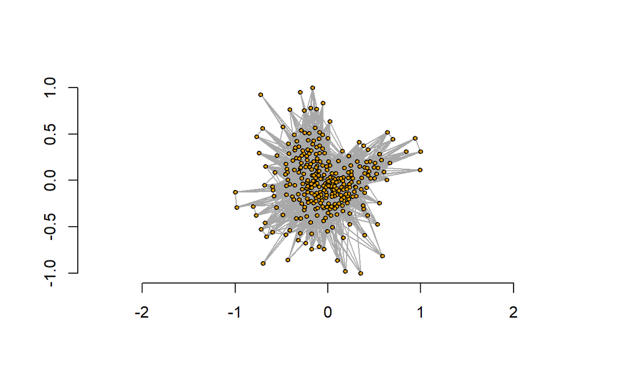

```r
V(network_igraph)$size<-5
V(network_igraph)$label.cex = 1/2
plot(network_igraph, layout_with_lgl(network_igraph), vertex.label=NA)
```

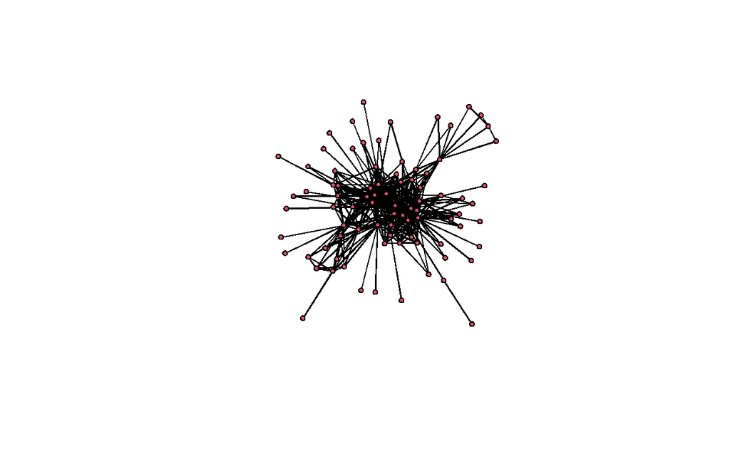

```r
#a subset of the data with a lot of weight on the edges- meaning more interactions between the characters
#weight chosen by rerunning until the plot is somewhat readable
sub_stat<-get.inducedSubgraph(network_statnet,eid=which(network_statnet%e%'weight'>10))
plot(sub_stat)
```

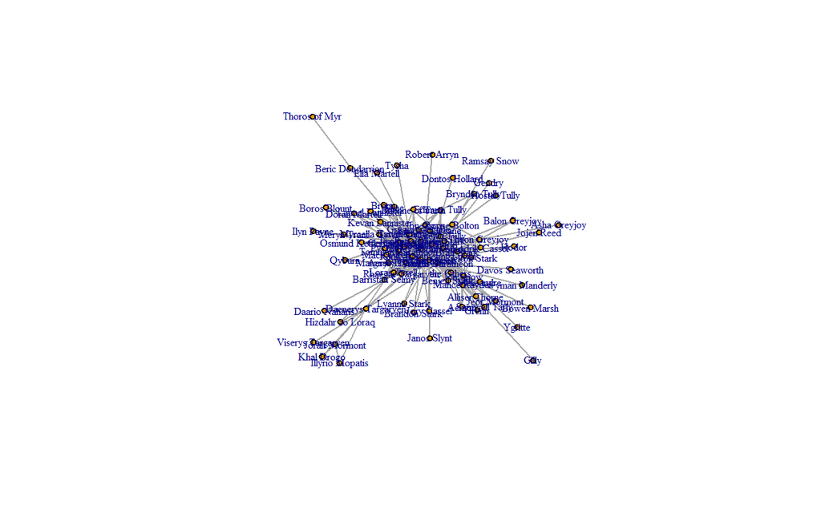

```r
#create the same igrpah subset
sub_igraph <- subgraph.edges(network_igraph, E(network_igraph)[E(network_igraph)$weight>10], del=F)
sub_igraph <- delete_vertices(sub_igraph, degree(sub_igraph, mode = "in")==0)

#format igrpah subset to be more readable
V(sub_igraph)$size<-5
V(sub_igraph)$label.cex = 1/2
#plot igrpah
plot(sub_igraph, layout=layout_nicely)
```

## Community Clusters

**I know that this is a big mess, but I couldn’t figure out how to make a subset of the network_nodes variable such that it has the same nodes as the above subgraphs. Which means that it is very dfficult to actually see and understand the created communites. So this is the code I have for now… I’ll hold off on analysis until I can figure out the nodes thing**

```r
#function to summarize the node statistics by community group
nodes.by.gp<-function(network.nodes, groupvar){
  network.nodes%>%
  select(-Name)%>%
  group_by_(groupvar) %>%
  mutate(n=n())%>%
  summarise_all(mean, na.rm=TRUE)%>%
  as.matrix()%>%
  print(digits=2)
}
```

### Fast and Greedy Detection

```r
#Run clustering algorithm: fast_greedy
got.fg<-cluster_fast_greedy(network_igraph)

#to get an idea of who is in what group
igraph::groups(network_igraph)
```

```
list()
```

```r
#blockmodel with community membership
print(blockmodel(network_statnet,got.fg$membership)$block.model, digits=2)
```

```
        Block 1 Block 2 Block 3 Block 4
Block 1   0.303   0.090    0.13   0.055
Block 2   0.090   0.500    0.20   0.051
Block 3   0.134   0.203    0.41   0.117
Block 4   0.055   0.051    0.12   0.500
```

```r
#add community membership as a node attribute
network_nodes$got.fg<-got.fg$membership

#summarize node statistics by community
nodes.by.gp(network_nodes,"got.fg")
```

```
     got.fg Appear   pov majorpov major   n
[1,]      1   12.7 0.118    0.094  0.14 127
[2,]      2   14.0 0.153    0.119  0.19  59
[3,]      3   15.0 0.071    0.071  0.13  99
[4,]      4    5.4 0.000    0.000  0.00  13
```

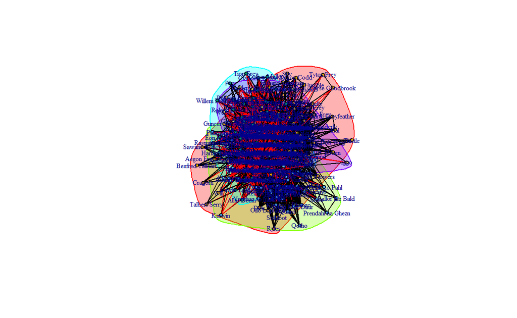

```r
#plot network with community coloringy
plot(got.fg,network_igraph, layout=layout_with_graphopt, max.sa.movement=10 )
```

### Walktrap Detection

```r
#Run clustering algorithm: walktrap
got.wt<-walktrap.community(network_igraph,steps=55)

#to get an idea of who is in what group
igraph::groups(got.wt)
```

```
$`1`
 [1] "Aegon Frey (Jinglebell)" "Aegon Targaryen"
 [3] "Allar Deem"              "Barra"
 [5] "Benjen Stark"            "Beric Dondarrion"
 [7] "Bronn"                   "Cersei Lannister"
 [9] "Chiswyck"                "Colemon"
[11] "Cortnay Penrose"         "Dick Crabb"
[13] "Dontos Hollard"          "Eddard Karstark"
[15] "Edmure Tully"            "Emmon Frey"
[17] "Garlan Tyrell"           "Gerris Drinkwater"
[19] "Gladden Wylde"           "Gregor Clegane"
[21] "Guyard Morrigen"         "Harlan Hunter"
[23] "Hizdahr zo Loraq"        "Hugh"
[25] "Illyrio Mopatis"         "Ilyn Payne"
[27] "Jaqen H'ghar"            "Jeyne Westerling"
```

[output cut: 160 more lines]

```r
#blockmodel with community membership
print(blockmodel(network_statnet,got.wt$membership)$block.model, digits=2)
```

```
        Block 1 Block 2 Block 3 Block 4 Block 5
Block 1    0.18    0.18    0.19    0.13    0.20
Block 2    0.18    0.27    0.20    0.22    0.26
Block 3    0.19    0.20    0.39    0.12    0.24
Block 4    0.13    0.22    0.12    0.19    0.19
Block 5    0.20    0.26    0.24    0.19    0.24
```

```r
#add community membership as a node attribute
network_nodes$got.wt<-got.wt$membership

#summarize node statistics by community
nodes.by.gp(network_nodes,"got.wt")
```

```
     got.wt Appear   pov majorpov major got.fg   n
[1,]      1     10 0.034    0.017 0.051    2.5  59
[2,]      2     16 0.137    0.118 0.176    1.7 102
[3,]      3     14 0.093    0.093 0.186    2.3  43
[4,]      4     12 0.085    0.068 0.119    1.7  59
[5,]      5     15 0.171    0.143 0.171    2.0  35
```

[figure not shown]

```r
#plot network with community coloring
plot(got.wt,network_igraph, layout=layout_with_graphopt, max.sa.movement=10 )
```

### Leading Label Propagation Detection

```r
#Run clustering algorithm: llp
got.lab<-label.propagation.community(network_igraph)

#to get an idea of who is in what group
igraph::groups(got.lab)
```

```
$`1`
  [1] "Addam Marbrand"
  [2] "Aegon Frey (Jinglebell)"
  [3] "Aegon I Targaryen"
  [4] "Aegon Targaryen"
  [5] "Aemon Targaryen"
  [6] "Aeron Greyjoy"
  [7] "Aerys II Targaryen"
  [8] "Alebelly"
  [9] "Alester Florent"
 [10] "Alfyn"
 [11] "Allar Deem"
 [12] "Amory Lorch"
 [13] "Antario Jast"
 [14] "Areo Hotah"
```

[output cut: 284 more lines]

```r
#blockmodel with community membership- doesn't work bc it is one group
#print(blockmodel(network_statnet, got.lab$membership)$block.model, digits=2)

#add community membership as a node attribute
network_nodes$got.lab<-got.lab$membership

#summarize node statistics by community
nodes.by.gp(network_nodes,"got.lab")
```

```
     got.lab Appear pov majorpov major got.fg got.wt   n
[1,]       1     13 0.1    0.087  0.14      2    2.7 298
```

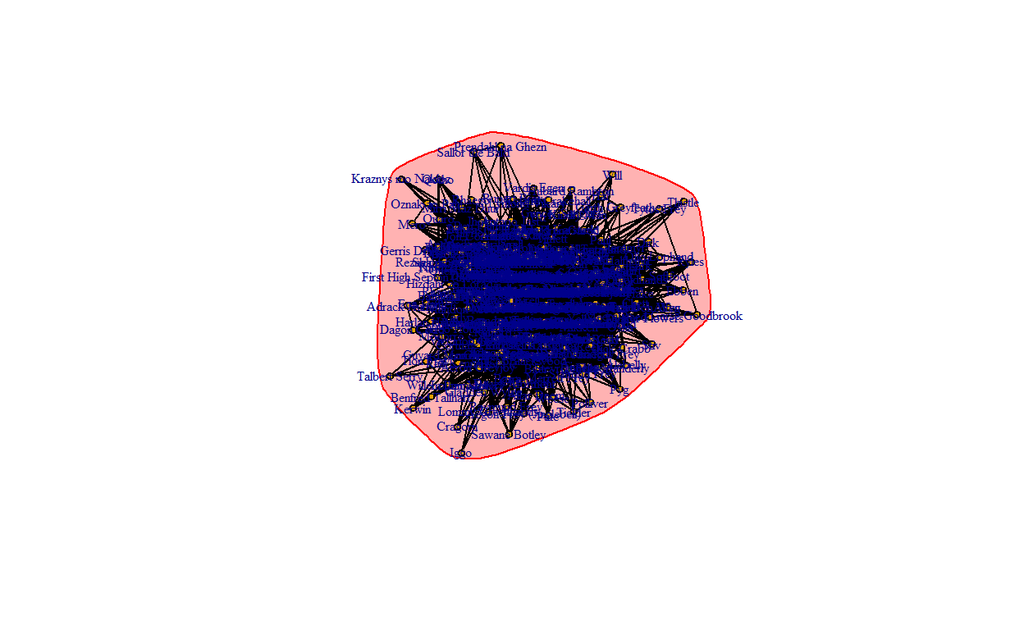

```r
#plot network with community coloring
plot(got.lab,network_igraph, layout=layout_with_graphopt, max.sa.movement=10 )
```

### Edge Betweenness Detection

Look, I tried (see code below if you want to figure out what went wrong) but this amost crashed my computer and it created over 100 groups, so I think its safe to say that this will not be a valid set of communities.

```r
#Run clustering algorithm: edge betweeness
got.edge<-edge.betweenness.community(network_igraph)

#to get an idea of who is in what group
igraph::groups(network_igraph)

#blockmodel with community membership
print(blockmodel(network_statnet,got.edge$membership)$block.model, digits=2)

#add community membership as a node attribute
network_nodes$got.edge<-got.edge$membership

#summarize node statistics by community
nodes.by.gp(network_nodes,"got.edge")

#plot network with community coloringy
plot(got.edge,network_igraph, layout=layout_with_graphopt, max.sa.movement=10 )
```

### Eigenvector Detection

```r
#Run clustering algorithm: eigenvector
got.eigen<-leading.eigenvector.community(network_igraph)

#to get an idea of who is in what group
igraph::groups(got.eigen)
```

```
$`1`
  [1] "Addam Marbrand"
  [2] "Alester Florent"
  [3] "Allar Deem"
  [4] "Amory Lorch"
  [5] "Antario Jast"
  [6] "Aron Santagar"
  [7] "Arys Oakheart"
  [8] "Aurane Waters"
  [9] "Balman Byrch"
 [10] "Balon Swann"
 [11] "Barra"
 [12] "Beric Dondarrion"
 [13] "Biter"
 [14] "Boros Blount"
```

[output cut: 180 more lines]

```r
#blockmodel with community membership
print(blockmodel(network_statnet,got.eigen$membership)$block.model, digits=2)
```

```
        Block 1 Block 2 Block 3 Block 4 Block 5
Block 1   0.411   0.174   0.180   0.100   0.018
Block 2   0.174   0.319   0.074   0.160   0.000
Block 3   0.180   0.074   0.518   0.052   0.137
Block 4   0.100   0.160   0.052   0.465   0.015
Block 5   0.018   0.000   0.137   0.015   1.000
```

```r
#add community membership as a node attribute
network_nodes$got.eigen<-got.eigen$membership

#summarize node statistics by community
nodes.by.gp(network_nodes,"got.eigen")
```

```
     got.eigen Appear   pov majorpov major got.fg got.wt got.lab   n
[1,]         1     16 0.072    0.072  0.15    3.0    2.4       1 111
[2,]         2     13 0.119    0.104  0.15    1.4    2.8       1  67
[3,]         3     11 0.157    0.118  0.14    2.0    2.8       1  51
[4,]         4     12 0.104    0.075  0.12    1.0    3.0       1  67
[5,]         5      1 0.000    0.000  0.00    2.0    3.0       1   2
```

[figure not shown]

```r
#plot network with community coloring
plot(got.eigen,network_igraph, layout=layout_with_graphopt, max.sa.movement=10 )
```

### Spinglass Community Detection

```r
#Run clustering algorithm: spinglass
got.spin<-spinglass.community(network_igraph)

#to get an idea of who is in what group
igraph::groups(got.spin)
```

```
$`1`
 [1] "Addam Marbrand"
 [2] "Aegon Targaryen"
 [3] "Aerys II Targaryen"
 [4] "Allar Deem"
 [5] "Antario Jast"
 [6] "Areo Hotah"
 [7] "Arianne Martell"
 [8] "Aron Santagar"
 [9] "Arys Oakheart"
[10] "Aurane Waters"
[11] "Balman Byrch"
[12] "Balon Swann"
[13] "Barra"
[14] "Boros Blount"
```

[output cut: 172 more lines]

```r
#blockmodel with community membership
print(blockmodel(network_statnet,got.spin$membership)$block.model, digits=2)
```

```
        Block 1 Block 2 Block 3 Block 4 Block 5
Block 1   0.496   0.197   0.168   0.011   0.116
Block 2   0.197   0.286   0.047   0.030   0.125
Block 3   0.168   0.047   0.576   0.056   0.035
Block 4   0.011   0.030   0.056     NaN   0.000
Block 5   0.116   0.125   0.035   0.000   0.445
```

```r
#add community membership as a node attribute
network_nodes$got.spin<-got.spin$membership

#summarize node statistics by community
nodes.by.gp(network_nodes,"got.spin")
```

```
     got.spin Appear  pov majorpov major got.fg got.wt got.lab
[1,]        1   17.8 0.11    0.109 0.217    2.8    2.5       1
[2,]        2   11.9 0.09    0.080 0.110    1.9    2.7       1
[3,]        3    9.9 0.11    0.083 0.083    2.0    2.7       1
[4,]        4    1.0 0.00    0.000 0.000    2.0    5.0       1
[5,]        5   11.7 0.12    0.072 0.116    1.1    3.0       1
     got.eigen   n
[1,]       1.3  92
[2,]       1.7 100
[3,]       3.1  36
[4,]       3.0   1
[5,]       3.9  69
```

[figure not shown]

```r
#plot network with community coloring
plot(got.spin,network_igraph, layout=layout_with_graphopt, max.sa.movement=10 )
```

### Compare Modularity

```r
mods<-c(fastgreedy=modularity(got.fg), walktrap=modularity(got.wt), llp=modularity(got.lab), eigen=modularity(got.eigen), spinglass=modularity(got.spin))

mods
```

```
fastgreedy   walktrap        llp      eigen  spinglass
0.25236488 0.02662821 0.00000000 0.26589769 0.14355753
```